# Assignment-2023, Semester 1

## Student Details:

- Name: P M J
- Date: 17 April 2023

## Task 1: Data Acquisition and Preparation

### Task1.1: Load the data into data frames

```python
import pandas as pd
import numpy as np

# Load each data set into a pandas data frame
data1 = pd.read_csv("data1.csv", sep=';')
data2 = pd.read_csv("data2.csv", sep=';')
data3 = pd.read_csv("data3.csv", sep=';')
```

To ensure that each data set has been loaded correctly I will check the heads of each data frame

```python
data1.head()
```

|  | ID | Marital status | Application mode | Application order | Course | Daytime/evening attendance | Previous qualification | Previous qualification (grade) | Nationality | Mother's qualification | ... | Father's occupation | Admission grade | Displaced | Educational special needs | Debtor | Tuition fees up to date | Gender | Scholarship holder | Age at enrollment | International |
| --- | --- | --- | --- | --- | --- | --- | --- | --- | --- | --- | --- | --- | --- | --- | --- | --- | --- | --- | --- | --- | --- |
| 0 | 2541 | 1 | 7 | 1 | 9147 | 1 | 3 | 120.0 | 1 | 1 | ... | 7 | 120.0 | 0 | 0 | 0 | 1 | 0 | 0 | 333 | 0 |
| 1 | 2554 | 1 | 17 | 1 | 9991 | 0 | 1 | 160.0 | 1 | 34 | ... | 0 | 161.8 | 1 | 0 | 1 | 1 | 1 | 0 | 333 | 0 |
| 2 | 2790 | 1 | 39 | 1 | 171 | 1 | 1 | 133.1 | 1 | 37 | ... | 7 | 100.0 | 0 | 0 | 1 | 1 | 1 | 1 | 333 | 0 |
| 3 | 2799 | 1 | 42 | 1 | 9500 | 1 | 1 | 150.0 | 1 | 19 | ... | 3 | 110.0 | 1 | 0 | 0 | 1 | 1 | 1 | 333 | 0 |
| 4 | 2883 | 2 | 39 | 1 | 9991 | 0 | 1 | 133.1 | 1 | 37 | ... | 9 | 113.4 | 0 | 0 | 0 | 1 | 0 | 0 | 333 | 0 |

5 rows × 22 columns

Data1 has a list of student IDs and information regarding their course of choice and enrollment information, such as their nationality, special needs or whether or not they are in debt to the university. It appears to me that "Age at enrollment" might contain impossible values.

```python
data2.head()
```

|  | ID | Curricular units 1st sem (credited) | Curricular units 1st sem (enrolled) | Curricular units 1st sem (evaluations) | Curricular units 1st sem (approved) | Curricular units 1st sem (grade) | Curricular units 1st sem (without evaluations) | Curricular units 2nd sem (credited) | Curricular units 2nd sem (enrolled) | Curricular units 2nd sem (evaluations) | Curricular units 2nd sem (approved) | Curricular units 2nd sem (grade) | Curricular units 2nd sem (without evaluations) | Unemployment rate | Inflation rate | GDP | Target |
| --- | --- | --- | --- | --- | --- | --- | --- | --- | --- | --- | --- | --- | --- | --- | --- | --- | --- |
| 0 | 1 | 0 | 0 | 0 | 0 | 0.0 | 0 | 0 | 0 | 0 | 0 | 0.0 | 0 | 10.8 | 1.4 | 1.74 | Dropout |
| 1 | 3 | 0 | 6 | 0 | 0 | 0.0 | 0 | 0 | 6 | 0 | 0 | 0.0 | 0 | 10.8 | 1.4 | 1.74 | Dropout |
| 2 | 8 | 0 | 5 | 5 | 0 | 0.0 | 0 | 0 | 5 | 5 | 0 | 0.0 | 0 | 15.5 | 2.8 | -4.06 | Dropout |
| 3 | 10 | 0 | 6 | 9 | 5 | 11.4 | 0 | 0 | 6 | 14 | 2 | 13.5 | 0 | 8.9 | 1.4 | 3.51 | Dropout |
| 4 | 13 | 0 | 6 | 6 | 0 | 0.0 | 0 | 0 | 6 | 0 | 0 | 0.0 | 0 | 12.7 | 3.7 | -1.70 | Dropout |

Data2 has information regarding the student's enrollment and grades from the first and second semester, as well as statistics regarding unemployment, inflation and GDP. I am unaware if the unemployment, inflation and GDP rates are based on their course of choice or not. The Target column gives me insight regarding whether or not they are on track with their academics or not.

```python
data3.head()
```

|  | ID | Marital status | Application mode | Application order | Course | Daytime/evening attendance | Previous qualification | Previous qualification (grade) | Nationality | Mother's qualification | ... | Curricular units 2nd sem (credited) | Curricular units 2nd sem (enrolled) | Curricular units 2nd sem (evaluations) | Curricular units 2nd sem (approved) | Curricular units 2nd sem (grade) | Curricular units 2nd sem (without evaluations) | Unemployment rate | Inflation rate | GDP | Target |
| --- | --- | --- | --- | --- | --- | --- | --- | --- | --- | --- | --- | --- | --- | --- | --- | --- | --- | --- | --- | --- | --- |
| 0 | 239 | 1 | 1 | 1 | 9130 | 1 | 1 | 126.0 | 1 | 19 | ... | 0 | 5 | 10 | 4 | 14.250000 | 0 | 9.4 | -0.8 | -3.12 | Dropout |
| 1 | 240 | 1 | 39 | 1 | 9085 | 1 | 19 | 133.1 | 1 | 19 | ... | 1 | 6 | 14 | 3 | 10.333333 | 0 | 16.2 | 0.3 | -0.92 | Dropout |
| 2 | 244 | 1 | 39 | 1 | 9147 | 1 | 1 | 120.0 | 1 | 37 | ... | 0 | 5 | 9 | 0 | 0.000000 | 0 | 10.8 | 1.4 | 1.74 | Dropout |
| 3 | 248 | 1 | 44 | 1 | 9003 | 1 | 39 | 130.0 | 1 | 37 | ... | 0 | 6 | 8 | 3 | 11.333333 | 0 | 13.9 | -0.3 | 0.79 | Dropout |
| 4 | 256 | 2 | 39 | 1 | 9556 | 1 | 19 | 133.1 | 1 | 38 | ... | 0 | 7 | 12 | 0 | 0.000000 | 0 | 8.9 | 1.4 | 3.51 | Dropout |

5 rows × 38 columns

Data3 has columns from both Data1 and Data2 but with a different set of students

### Task1.2: Merge the data frames into one where each student has a unique ID and is described by all 38 attributes

```python
# Merging data1 and data2 is straightforward but merging the newly merged set with data3 requires
# a different approach

merged_dataset = data1.merge(data2, on="ID")

# To merge the merged_dataset with data3 I will concatenate the sets

all_data = pd.concat([merged_dataset, data3], ignore_index=True)

# Print the all_data merged data set
all_data
```

|  | ID | Marital status | Application mode | Application order | Course | Daytime/evening attendance | Previous qualification | Previous qualification (grade) | Nationality | Mother's qualification | ... | Curricular units 2nd sem (credited) | Curricular units 2nd sem (enrolled) | Curricular units 2nd sem (evaluations) | Curricular units 2nd sem (approved) | Curricular units 2nd sem (grade) | Curricular units 2nd sem (without evaluations) | Unemployment rate | Inflation rate | GDP | Target |
| --- | --- | --- | --- | --- | --- | --- | --- | --- | --- | --- | --- | --- | --- | --- | --- | --- | --- | --- | --- | --- | --- |
| 0 | 2541 | 1 | 7 | 1 | 9147 | 1 | 3 | 120.0 | 1 | 1 | ... | 0 | 5 | 5 | 0 | 0.000000 | 0 | 12.4 | 0.5 | 1.79 | Drpout |
| 1 | 2554 | 1 | 17 | 1 | 9991 | 0 | 1 | 160.0 | 1 | 34 | ... | 0 | 5 | 5 | 0 | 0.000000 | 0 | 7.6 | 2.6 | 0.32 | Dropout |
| 2 | 2790 | 1 | 39 | 1 | 171 | 1 | 1 | 133.1 | 1 | 37 | ... | 0 | 0 | 0 | 0 | 0.000000 | 0 | 15.5 | 2.8 | -4.06 | Dropout |
| 3 | 2799 | 1 | 42 | 1 | 9500 | 1 | 1 | 150.0 | 1 | 19 | ... | 6 | 14 | 20 | 14 | 13.072857 | 6 | 9.4 | -0.8 | -3.12 | Graduate |
| 4 | 2883 | 2 | 39 | 1 | 9991 | 0 | 1 | 133.1 | 1 | 37 | ... | 0 | 5 | 13 | 2 | 12.000000 | 0 | 12.4 | 0.5 | 1.79 | Dropout |
| ... | ... | ... | ... | ... | ... | ... | ... | ... | ... | ... | ... | ... | ... | ... | ... | ... | ... | ... | ... | ... | ... |
| 4419 | 1841 | 1 | 10 | 1 | 9773 | 1 | 1 | 151.0 | 22 | 38 | ... | 0 | 6 | 0 | 0 | 0.000000 | 0 | 9.4 | -0.8 | -3.12 | Dropout |
| 4420 | 1889 | 1 | 10 | 1 | 9085 | 1 | 1 | 184.4 | 22 | 2 | ... | 0 | 6 | 10 | 5 | 14.333333 | 0 | 11.1 | 0.6 | 2.02 | Graduate |
| 4421 | 2420 | 1 | 39 | 1 | 9003 | 1 | 1 | 133.1 | 6 | 1 | ... | 0 | 6 | 9 | 5 | 13.400000 | 0 | 8.9 | 1.4 | 3.51 | Enrolled |
| 4422 | 2454 | 1 | 15 | 1 | 171 | 1 | 1 | 130.0 | 26 | 1 | ... | 4 | 11 | 15 | 11 | 13.083333 | 0 | 8.9 | 1.4 | 3.51 | Enrolled |
| 4423 | 2499 | 1 | 39 | 1 | 171 | 1 | 19 | 133.1 | 101 | 1 | ... | 0 | 0 | 0 | 0 | 0.000000 | 0 | 15.5 | 2.8 | -4.06 | Dropout |

4424 rows × 38 columns

```python
# I want to see the names of all 38 columns
print(all_data.columns)
```

```
Index(['ID', 'Marital status', 'Application mode', 'Application order',
       'Course', 'Daytime/evening attendance', 'Previous qualification',
       'Previous qualification (grade)', 'Nationality',
       'Mother's qualification', 'Father's qualification',
       'Mother's occupation', 'Father's occupation', 'Admission grade',
       'Displaced', 'Educational special needs', 'Debtor',
       'Tuition fees up to date', 'Gender', 'Scholarship holder',
       'Age at enrollment', 'International',
       'Curricular units 1st sem (credited)',
       'Curricular units 1st sem (enrolled)',
       'Curricular units 1st sem (evaluations)',
       'Curricular units 1st sem (approved)',
       'Curricular units 1st sem (grade)',
       'Curricular units 1st sem (without evaluations)',
       'Curricular units 2nd sem (credited)',
       'Curricular units 2nd sem (enrolled)',
       'Curricular units 2nd sem (evaluations)',
       'Curricular units 2nd sem (approved)',
       'Curricular units 2nd sem (grade)',
       'Curricular units 2nd sem (without evaluations)', 'Unemployment rate',
       'Inflation rate', 'GDP', 'Target'],
      dtype='object')
```

The three datasets have been merged into one succesfully, with the merged dataset having all 38 attributes. It took me a while to merge the data as I had not added the sep='; '!

```python
print(all_data.info())
```

```
<class 'pandas.core.frame.DataFrame'>
RangeIndex: 4424 entries, 0 to 4423
Data columns (total 38 columns):
 #   Column                                          Non-Null Count  Dtype
---  ------                                          --------------  -----
 0   ID                                              4424 non-null   int64
 1   Marital status                                  4424 non-null   int64
 2   Application mode                                4424 non-null   int64
 3   Application order                               4424 non-null   int64
 4   Course                                          4424 non-null   int64
 5   Daytime/evening attendance                      4424 non-null   object
 6   Previous qualification                          4424 non-null   int64
 7   Previous qualification (grade)                  4424 non-null   float64
 8   Nationality                                     4424 non-null   int64
 9   Mother's qualification                          4424 non-null   int64
```

[output cut: 31 more lines]

### Task 1.3: Clean the data

```python
print(all_data.shape)
```

```
(4424, 38)
```

```python
# Check for missing values
missing_values = all_data.isna().any()

# Print columns with missing values
print("Columns with missing values:")
print(missing_values[missing_values == True].index)

# Check for duplicate values
duplicate_rows = all_data.duplicated()
if duplicate_rows.any():
    print("Duplicate rows found!")
else:
    print("No duplicate rows found.")
```

```
Columns with missing values:
Index(['Tuition fees up to date', 'International'], dtype='object')
No duplicate rows found.
```

```python
# Check the age at enrollment column
print(all_data["Age at enrollment"])
print(all_data["Age at enrollment"].unique())
# 333, 444 and 222 are data entry errors. I will correct them now
all_data["Age at enrollment"] = all_data["Age at enrollment"].replace({333: 33, 444: 44, 222: 22})
print("Unique values after correction:")
print(all_data["Age at enrollment"].unique())
```

[output not shown]

```python
# Check the target column as I can see a spelling mistake in the head of all_data
print(all_data["Target"].unique())
# There are several spelling mistakes
all_data["Target"] = all_data["Target"].replace({"Drpout": "Dropout", "Dropot": "Dropout", "Grduate": "Graduate", "enroled": "Enrolled"})
print("Target column values after amendment: ")
print(all_data["Target"].unique())
```

[output not shown]

```python
# Give that there might be other errors, I will print out all unique values of all columns
for column in all_data.columns:
    unique_values = all_data[column].unique()
    print("Unique values in column ", column, "are: ", unique_values)
```

```
Unique values in column  ID are:  [2541 2554 2790 ... 2420 2454 2499]
Unique values in column  Marital status are:  [1 2 4 5 6 3]
Unique values in column  Application mode are:  [ 7 17 39 42 43 44  2 51 27  1 15 18 57 26 53  5 10 16]
Unique values in column  Application order are:  [1 2 3 4 9 5 6 0]
Unique values in column  Course are:  [9147 9991  171 9500 9119 9238 9254 9853 9130 8014 9003 9773 9556 9670
 9070 9085   33]
Unique values in column  Daytime/evening attendance are:  ['1' '0' 'Y' 1 0]
Unique values in column  Previous qualification are:  [ 3  1 42 19 39 12 38  2  9 10  4 40  6 43 14  5 15]
Unique values in column  Previous qualification (grade) are:  [120.  160.  133.1 150.  130.  110.  170.  140.  100.  149.  135.  114.
 111.  123.  165.  136.  161.  146.  190.  126.6 113.  151.  116.  138.
 180.  137.  168.  155.  133.  147.  126.  134.  143.  129.  124.4 117.
 148.  154.  125.  132.  141.  127.  172.  133.8 139.3 115.  144.  138.7
 145.  118.  121.  128.  122.  119.  139.  145.7 109.  162.  131.  152.
 164.  124.  103.   99.  156.  107.  108.  142.  101.  119.1 157.  106.
 112.  117.4 102.  153.  163.  105.  158.  148.9 123.9 167.  175.  118.9
 159.  178.  176.  174.  182.  154.4 163.3 169.  177.   95.  188.   96.
 166.   97.  140.8 138.6 184.4]
Unique values in column  Nationality are:  [  1   6  21  41 100  25 105  22  26  24  62 101  11 103  13  32  14  17
   2 108 109]
Unique values in column  Mother's qualification are:  [ 1 34 37 19 38  2 35  3  5 12 40 44  6 11 36 27 41  4  9 39 43 29 42 10
 14 22 26 30 18]
Unique values in column  Father's qualification are:  ['39' '34' '37' '1' '38' '19' '2' '3' '35' '11' '25' '5' '26' '40' '41'
 '4' '22' '20' '29' '31' '36' '6' '12' '9' '27' '14' '10' '44' '33' '13'
 '30' '          ' '18' '43' 1 19 37 38 4 3 34 2 39 12 5 11 9 36 14 43 22
 42 41 10 6 40 30]
Unique values in column  Mother's occupation are:  [  4   0   9   8   1   2  90   6   3  10   7   5  99 192 144 194 175 191
 151 134 171 193 152 153 141 143 125 132 123 122 131 173]
Unique values in column  Father's occupation are:  [  7   0   3   9   4   8   6   1  10   2  90   5  99 141 131 103 193 192
 123 152 163 161 134 144 153 135 112 114 151 172 181 171 102 182 124 132
 143 183 174 154 175 101 194 122 121 195]
Unique values in column  Admission grade are:  [120.  161.8 100.  110.  113.4 149.  159.5 130.  139.  138.3 108.  155.9
 116.4 103.  135.1 140.  135.5 154.  122.9 126.3 162.5 169.2 104.  170.
 112.5 118.  129.8 135.  159.  144.  114.8 148.8 163.5  96.  119.9 121.
 123.5 110.7 113.5  95.  128.  134.1 162.  150.  106.8 116.7 162.4 100.9
 151.1 149.5 106.  119.   98.5 124.3 148.3 122.5 150.3 134.5 148.5 107.
 133.  128.2 109.  113.  114.6 104.8 117.8 141.5 162.9 121.7 160.  132.8
 112.  168.2 144.5 122.7 114.  103.5 157.  120.5 157.8 154.6 128.8 190.
 125.7 100.5 138.7 142.8 133.2 135.6 138.  136.1 107.5 122.8 137.7 136.
 144.3 117.2 139.4 125.2 114.3 115.  125.  121.9 143.  152.4 147.8 117.9
 153.  134.  113.9 115.5 120.4 146.5 155.5 117.5 130.2 147.5 120.7 118.1
```

[output cut: 316 more lines]

```
 12.82857143 13.03333333 10.92307692 13.24875    15.61111111 16.14285714
 12.28125    11.65       14.81818182 12.91111111 14.65555556 14.36
 14.51428571 14.7        15.0625     15.7425     15.075      13.76125
 14.07777778 14.02222222 15.63375    12.45       13.38125    13.3425
 13.03125    13.35714286 13.05375    15.57       15.91111111 13.07571429
 13.51285714 12.288      13.54444444 14.86444444 13.4275     12.36111111
 12.68888889 13.55714286 14.63636364 11.725      12.18333333 13.435
 12.17647059 12.74285714 13.12857143 14.93571429 13.90625    12.4875
 14.08571429 11.50625    14.3        11.7125     15.88571429 11.35714286
 17.69230769 11.34714286]
Unique values in column  Curricular units 2nd sem (without evaluations) are:  [ 0  6  1  2  5  3  4  7  8 12]
Unique values in column  Unemployment rate are:  [12.4  7.6 15.5  9.4 11.1  8.9 12.7 16.2 10.8 13.9]
Unique values in column  Inflation rate are:  [ 0.5  2.6  2.8 -0.8  0.6  1.4  3.7  0.3 -0.3]
Unique values in column  GDP are:  [ 1.79  0.32 -4.06 -3.12  2.02  3.51 -1.7  -0.92  1.74  0.79]
Unique values in column  Target are:  ['Dropout' 'Graduate' 'Enrolled']
```

```python
# I will round all values to 2 decimal places in the Curricular units columns for 1st and 2nd sem.
all_data["Curricular units 1st sem (grade)"] = all_data["Curricular units 1st sem (grade)"].round(2)
all_data["Curricular units 2nd sem (grade)"] = all_data["Curricular units 2nd sem (grade)"].round(2)
print("Rounded values in 1st sem:")
print(all_data["Curricular units 1st sem (grade)"].unique())
print("Rounded values in 2nd sem:")
print(all_data["Curricular units 2nd sem (grade)"].unique())
```

```
Rounded values in 1st sem:
[14.   10.5   0.   13.07 10.   12.   12.83 13.3  13.06 12.42 12.86 13.
 12.6  15.71 15.   14.11 12.75 13.33 12.4  14.2  11.75 13.83 11.4  14.33
 12.46 14.31 11.   11.8  13.18 15.2  11.6  11.86 12.5  11.33 12.67 13.25
 12.29 12.33 10.67 13.11 14.73 11.5  14.8  12.2  14.62 11.38 12.21 13.67
 12.7  12.17 12.44 10.25 13.5  13.6  11.88 11.85 14.83 13.75 14.63 13.88
 14.17 12.25 11.64 13.8  16.4  12.88 11.2  11.67 14.45 12.62 11.92 12.68
 14.5  14.64 11.83 14.3  16.   11.62 15.89 11.25 17.33 10.6  13.77 13.42
 13.22 10.93 12.64 13.13 12.18 10.75 12.89 12.22 14.6  15.8  14.12 13.73
 13.43 11.73 16.5  10.99 12.48 12.78 12.35  9.8  13.57 10.83 13.63 16.17
 12.8  13.62 11.56 12.14 10.64 10.4  13.84 11.71 16.14 12.51 12.07 17.
 11.43 14.71 14.35 18.   13.2  10.38 11.29 13.7  14.66 10.21 12.69 12.76
 11.14 10.33 13.45 10.2  13.74 14.75 12.85 13.76 13.82 15.47 12.56 10.9
 14.4  13.17 13.44 11.46 14.69 12.53 16.43 12.27 13.4  15.68 14.91 11.9
 14.26 11.45 15.44 16.11 16.33 15.33 17.11 11.77 11.32 14.53 13.39 14.88
 17.01 12.43 12.79 13.38 10.29 14.43 11.89 12.08 13.71 14.95 11.07 12.23
 11.42 14.41 14.67 15.94 13.81 13.29 12.12 10.98 15.43 13.05 11.57 10.82
 12.04 11.61 12.57 13.37 14.81 11.95 14.14 16.86 12.58 11.69 11.17 10.77
 11.98 16.89 12.61 13.47 15.75 13.12 14.86 12.71 13.14 10.71 12.36 14.99
 10.8  11.36 12.16 11.97 12.41 13.56 10.86 10.89 13.86 15.57 14.36 12.38
 14.38 12.99 13.15 10.92 12.1  11.94 13.48 15.09 12.73 15.08 13.93 13.52
 14.84 13.08 14.25 12.55 10.37 14.58 15.17 13.9  13.31 10.74 10.57 11.78
 12.09 15.83 13.1  11.68 11.55 14.7  12.45 14.07 13.27 13.34 11.91 13.26
 14.93 14.54 12.24 13.96 12.91 13.51 11.44 13.19 12.82 15.5  15.14 13.46
 13.91 14.46 12.98 14.9  13.92 13.02 14.37 15.03 13.59 12.49 12.72 14.29
 12.63 14.57 12.15 13.98 14.01 15.4  16.71 15.86 12.84 15.25 11.96 13.68
 13.79 13.55 15.69 15.05 14.85 16.83 11.23 16.13 13.78 14.09 12.74 12.47
 12.93 12.34 13.36 13.41 14.24 13.09 14.1  14.05 14.79 13.53 12.94 13.58
 11.99 13.04 14.27 12.81 13.54 12.97 14.13 14.15 10.88 14.28 15.12 13.23
 14.98 13.87 14.06 11.66 11.72 11.82 12.65 14.23 12.32 14.76 15.11 12.77
 13.89 12.19 13.64 11.15 12.66 12.9  13.94 11.12 14.34 14.21 13.95 15.54
 15.31 13.35 13.21 14.94 12.52 13.24 17.12 14.92 15.96 12.54 15.38 11.84
 14.02 14.68 12.95 15.29 15.23 15.01 14.44 12.11 13.49 14.65 15.07 16.9
 11.79 16.46 15.66 14.87 13.03 14.04 13.97 12.92 15.7  15.16 13.61 12.39
 14.96 11.16 11.58 13.28 15.67 14.42 14.32 15.3  14.49 16.2  15.1  13.69
 14.59 12.59 12.37 13.01 14.72 13.85 14.89 15.62 11.76 10.69 16.15 14.03
 11.27 11.59 11.3  12.3  11.81 10.47 14.51 16.57 15.63 14.18 11.54 10.17
 14.22 14.78 18.88]
Rounded values in 2nd sem:
[ 0.   13.07 12.   13.67 13.73 13.   12.67 14.   11.25 15.5  12.83 14.23
```

[output cut: 21 more lines]

```
 12.63 14.57 17.17 15.83 14.01 11.77 16.33 13.04 13.89 14.78 17.71 14.47
 12.49 14.85 11.78 12.65 15.01 13.09 11.74 12.78 14.21 15.52 15.56 13.06
 12.74 12.18 12.47 13.72 12.36 14.44 11.18 12.82 15.35 14.1  15.1  15.86
 12.24 13.61 14.07 13.76 13.58 13.93 15.88 11.99 12.34 12.31 14.27 14.22
 14.37 13.44 13.39 14.15 13.05 15.09 13.23 14.98 13.87 11.56 15.92 11.24
 15.17 12.32 11.82 12.19 10.71 14.76 15.37 12.77 14.06 14.35 12.45 14.39
 12.81 12.66 13.94 12.39 13.54 15.13 13.65 13.95 15.43 14.45 12.05 13.53
 15.64 15.2  13.35 11.26 14.94 14.48 17.59 15.36 12.93 11.72 15.19 14.56
 15.81 11.98 16.43 14.63 13.34 12.95 14.02 16.08 17.43 13.19 14.88 16.09
 15.16 15.07 11.79 18.57 13.41 13.99 15.66 13.45 13.68 14.04 13.24 13.97
 15.12 15.7  14.77 13.59 14.79 13.98 14.31 15.08 13.28 14.19 14.53 14.72
 10.87 14.32 15.3  14.03 14.59 13.27 13.47 12.37 15.75 13.01 15.25 13.52
 10.38 14.24 14.92 11.34 14.91 15.39 14.73 16.17 11.11 13.92 11.3  16.05
 14.09 12.13 10.84 13.03 10.92 15.61 16.14 12.28 11.65 14.82 14.7  14.08
 15.63 13.36 15.91 14.64 11.51 14.3  15.89 17.69 11.35]
```

## Task 2: Data Exploration

### Task 2.1: Data visualisation of two columns

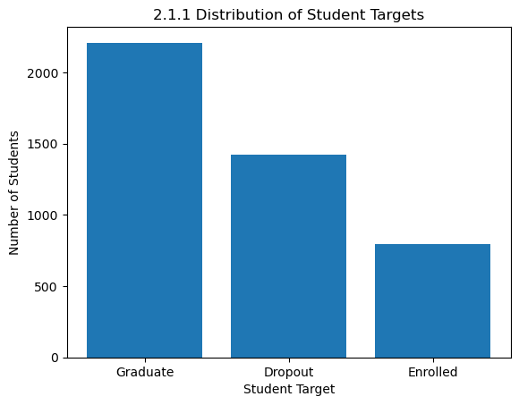

```python
# For the column with categorical values, it makes a lot of sense to me to analyze the Target column.
# This column tells us the status of a particular student
# I would like to see how many students are in each category of Target

import matplotlib.pyplot as plt

target_counts = all_data['Target'].value_counts()

plt.bar(target_counts.index, target_counts.values)
plt.xlabel('Student Target')
plt.ylabel('Number of Students')
plt.title('2.1.1 Distribution of Student Targets')
plt.show()
```

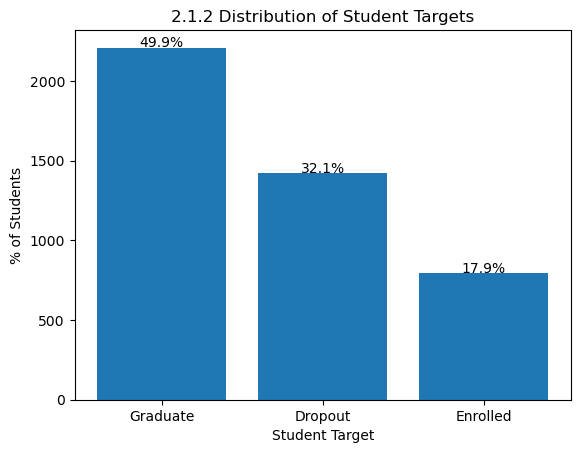

```python
# We can see that most students will graduate but more will dropout rather than enroll.
# I think it would make more sense to show the % of each category in the graph rather than the raw statistics

percentages = target_counts / len(all_data) * 100
plt.bar(target_counts.index, target_counts.values)

for i, count in enumerate(target_counts):
    plt.text(i, count+5, f"{percentages[i]:.1f}%", ha='center')

plt.title('2.1.2 Distribution of Student Targets')
plt.xlabel('Student Target')
plt.ylabel('% of Students')

plt.show()
```

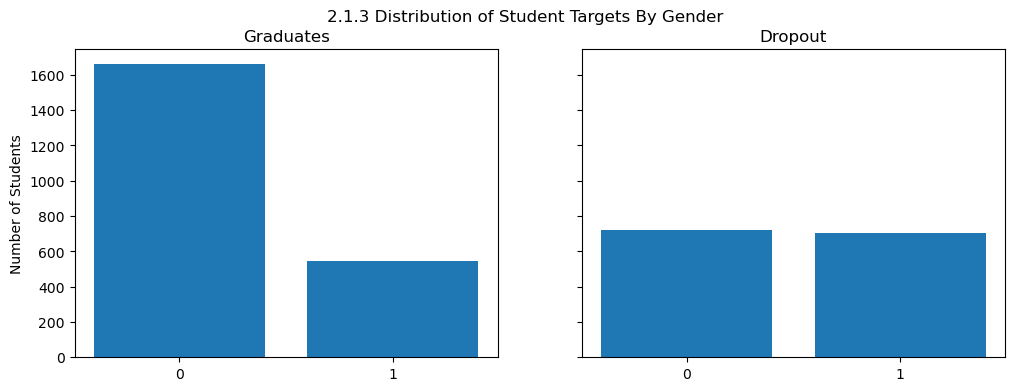

```python
# It will give us more information to add the gender split of all student Targets
import matplotlib.pyplot as plt

# Create separate dataframes for each target category
graduates_df = all_data[all_data['Target'] == 'Graduate']
dropout_df = all_data[all_data['Target'] == 'Dropout']
enrolled_df = all_data[all_data['Target'] == 'Enroll']


graduates_gender_counts = graduates_df['Gender'].value_counts()
dropout_gender_counts = dropout_df['Gender'].value_counts()


# Create bar graphs for each target category with gender split
fig, axs = plt.subplots(1, 2, figsize=(12, 4), sharey=True)

axs[0].bar([0, 1], graduates_gender_counts.values)
axs[0].set_title('Graduates')
axs[0].set_xticks([0, 1])
axs[0].set_xticklabels(['0', '1'])
axs[1].bar([0, 1], dropout_gender_counts.values)
axs[1].set_title('Dropout')
axs[1].set_xticks([0, 1])
axs[1].set_xticklabels(['0', '1'])



axs[0].set_ylabel('Number of Students')
fig.suptitle('2.1.3 Distribution of Student Targets By Gender')
plt.show()
```

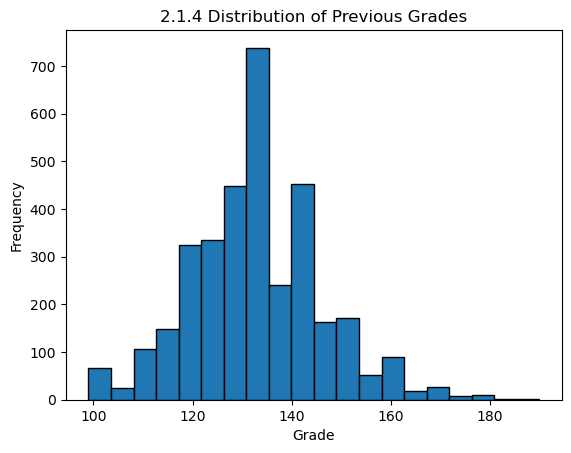

```python
# The numerical column I will visualise is the Previous qualification (grade) column.
# This will allow me to see the average grades of students when they applied.
# When I plot this on a histogram, I will clearly see the normal distribution of all students grades.

fig, ax = plt.subplots()
ax.hist(merged_dataset["Previous qualification (grade)"], bins=20, edgecolor='black')
ax.set_title("2.1.4 Distribution of Previous Grades")
ax.set_xlabel("Grade")
ax.set_ylabel("Frequency")
plt.show()
```

### Task 2.2: Relationships between columns

```
Scholarship holder mean: 133.89699727024578
Non-scholarship holder mean: 132.18902255639046
```

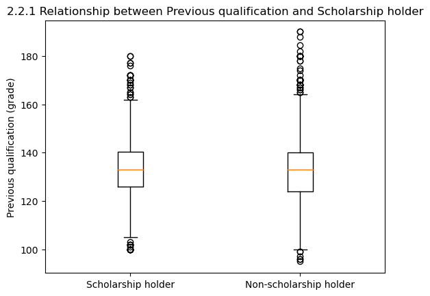

```python
# I will check the grades of students prior to enrollment and whether or not the candidate received a scholarship by using box plots

# Mean of the "Previous qualification (grade)" column for each group
scholarship_mean = all_data[all_data['Scholarship holder'] == 1]['Previous qualification (grade)'].mean()
non_scholarship_mean = all_data[all_data['Scholarship holder'] == 0]['Previous qualification (grade)'].mean()

# Print the mean for each group
print("Scholarship holder mean:", scholarship_mean)
print("Non-scholarship holder mean:", non_scholarship_mean)

# Create a box plot of the "Previous qualification (grade)" column for each group
fig, ax = plt.subplots()
ax.boxplot([all_data[all_data['Scholarship holder'] == 1]['Previous qualification (grade)'],
            all_data[all_data['Scholarship holder'] == 0]['Previous qualification (grade)']])
ax.set_xticklabels(['Scholarship holder', 'Non-scholarship holder'])
ax.set_ylabel('Previous qualification (grade)')
ax.set_title('2.2.1 Relationship between Previous qualification and Scholarship holder')

# Show the plot
plt.show()
```

I am surprised to see that the average grade of a scholarship holder is only slightly above that of a non-scholarship holder. I also observe that some non-scholarship holders have received higher grades than scholarship holders.

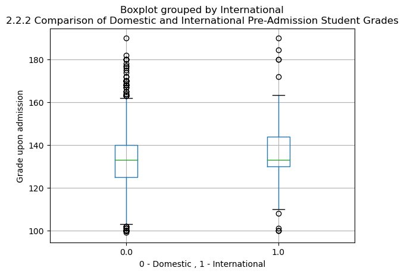

```python
# I will compare the pre-admission grades of domestic and international students

# Create a boxplot of the "Previous qualification (grade)" column for each group
fig, ax = plt.subplots()
all_data.boxplot(column='Previous qualification (grade)', by='International', ax=ax)

# Set the x and y axis labels and the title of the plot
ax.set_xlabel('0 - Domestic , 1 - International')
ax.set_ylabel('Grade upon admission')
ax.set_title('2.2.2 Comparison of Domestic and International Pre-Admission Student Grades')

# Show the plot
plt.show()
```

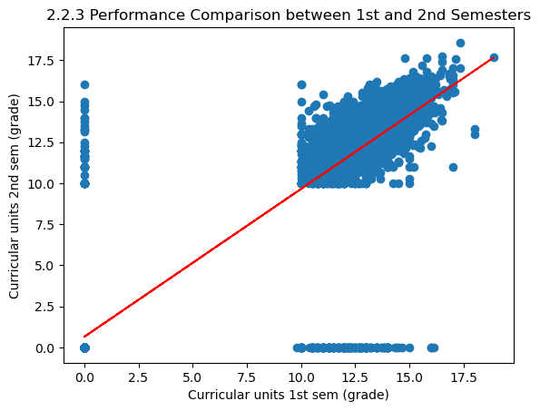

```python
# I now want to examine the grades of students from the 1st and 2nd semester
# Create a scatter plot of the "Curricular units 1st sem (grade)" and "Curricular units 2nd sem (grade)" columns
fig, ax = plt.subplots()
ax.scatter(all_data['Curricular units 1st sem (grade)'], all_data['Curricular units 2nd sem (grade)'])

z = np.polyfit(all_data['Curricular units 1st sem (grade)'], all_data['Curricular units 2nd sem (grade)'], 1)
p = np.poly1d(z)
ax.plot(all_data['Curricular units 1st sem (grade)'], p(all_data['Curricular units 1st sem (grade)']), "r--")


# Set the x and y axis labels and the title of the plot
ax.set_xlabel('Curricular units 1st sem (grade)')
ax.set_ylabel('Curricular units 2nd sem (grade)')
ax.set_title('2.2.3 Performance Comparison between 1st and 2nd Semesters')

# Show the plot
plt.show()
```

The graph shows that there is a strong relationship between doing well in the first semester and doing well in the second semester, great students!

However, there are outliers in the data set which must be removed.

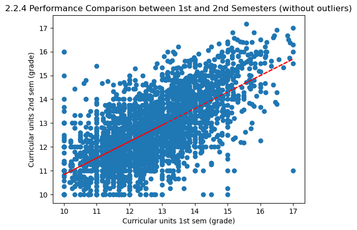

```python
k = 1.5

# Calculate the IQR and the bounds for each column
q1_1st = np.percentile(all_data['Curricular units 1st sem (grade)'], 25)
q3_1st = np.percentile(all_data['Curricular units 1st sem (grade)'], 75)
iqr_1st = q3_1st - q1_1st
lower_bound_1st = q1_1st - k * iqr_1st
upper_bound_1st = q3_1st + k * iqr_1st

q1_2nd = np.percentile(all_data['Curricular units 2nd sem (grade)'], 25)
q3_2nd = np.percentile(all_data['Curricular units 2nd sem (grade)'], 75)
iqr_2nd = q3_2nd - q1_2nd
lower_bound_2nd = q1_2nd - k * iqr_2nd
upper_bound_2nd = q3_2nd + k * iqr_2nd

# Identify and remove the outliers
filtered_data = all_data[(all_data['Curricular units 1st sem (grade)'] >= lower_bound_1st) & (all_data['Curricular units 1st sem (grade)'] <= upper_bound_1st) & (all_data['Curricular units 2nd sem (grade)'] >= lower_bound_2nd) & (all_data['Curricular units 2nd sem (grade)'] <= upper_bound_2nd)]

# Create a scatter plot with the filtered data
fig, ax = plt.subplots()
ax.scatter(filtered_data['Curricular units 1st sem (grade)'], filtered_data['Curricular units 2nd sem (grade)'])

# Add a regression line to the plot
z = np.polyfit(filtered_data['Curricular units 1st sem (grade)'], filtered_data['Curricular units 2nd sem (grade)'], 1)
p = np.poly1d(z)
ax.plot(filtered_data['Curricular units 1st sem (grade)'], p(filtered_data['Curricular units 1st sem (grade)']), "r--")

# Set the x and y axis labels and the title of the plot
ax.set_xlabel('Curricular units 1st sem (grade)')
ax.set_ylabel('Curricular units 2nd sem (grade)')
ax.set_title('2.2.4 Performance Comparison between 1st and 2nd Semesters (without outliers)')

# Show the plot
plt.show()
```

### Task 2.3: 6 Variable scatter plot

I have chosen the following columnns:

- Unemployment rate
- Inflation rate
- GDP
- Curricular units 1st sem (grade)
- Curricular units 2nd sem (grade)
- Previous qualification (grade)

I want to see the relationship between high academic performance and the unemployment and inflation rate and GDP

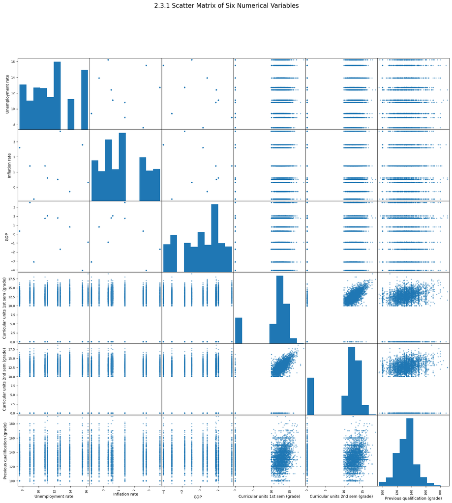

```python
# Select the six numerical columns
num_cols = ['Unemployment rate', 'Inflation rate', 'GDP', 'Curricular units 1st sem (grade)',
            'Curricular units 2nd sem (grade)', 'Previous qualification (grade)']

# Create the scatter matrix using the selected columns
pd.plotting.scatter_matrix(all_data[num_cols], figsize=(20, 20))

# Show the plot
plt.suptitle('2.3.1 Scatter Matrix of Six Numerical Variables', size=16)
plt.show()
```

[figure not shown]

```python
# Define the threshold multiplier
k = 1.5

# Calculate the IQR and the bounds for each numerical column
bounds = {}
for col in num_cols:
    q1 = np.percentile(all_data[col], 25)
    q3 = np.percentile(all_data[col], 75)
    iqr = q3 - q1
    lower_bound = q1 - k * iqr
    upper_bound = q3 + k * iqr
    bounds[col] = (lower_bound, upper_bound)

# Identify and remove the outliers from each numerical column
filtered_data = all_data.copy()
for col in num_cols:
    filtered_data = filtered_data[(filtered_data[col] >= bounds[col][0]) & (filtered_data[col] <= bounds[col][1])]

# Create a scatter matrix plot with the filtered data
pd.plotting.scatter_matrix(filtered_data[num_cols], figsize=(20, 20))

# Set the title of the plot
plt.suptitle('2.3.2 Scatter Matrix of Six Numerical Variables (without outliers)', size=16)

# Show the plot
plt.show()
```